# Project Phase 2

Alex Song

2026-03-07

- instant: record index
- dteday : date c - season : season (1:springer, 2:summer, 3:fall, 4:winter) c - yr : year (0: 2011, 1:2012) c - mnth : month ( 1 to 12) c - holiday : weather day is holiday or not (extracted from http://dchr.dc.gov/page/holiday-schedule) c - weekday : day of the week c - workingday : if day is neither weekend nor holiday is 1, otherwise is 0. c - weathersit :
  - 1: Clear, Few clouds, Partly cloudy, Partly cloudy
  - 2: Mist + Cloudy, Mist + Broken clouds, Mist + Few clouds, Mist
  - 3: Light Snow, Light Rain + Thunderstorm + Scattered clouds, Light Rain + Scattered clouds
  - 4: Heavy Rain + Ice Pallets + Thunderstorm + Mist, Snow + Fog
- temp : Normalized temperature in Celsius. The values are divided to 41 (max)
- atemp: Normalized feeling temperature in Celsius. The values are divided to 50 (max)
- hum: Normalized humidity. The values are divided to 100 (max)
- windspeed: Normalized wind speed. The values are divided to 67 (max)
- casual: count of casual users
- registered: count of registered users
- cnt: count of total rental bikes including both casual and registered

### Loading and preparing the data

```r
set.seed(123)

bike <- read.csv("C:/Users/alexm/Desktop/DATA 5321/Project/bike_sharing_daily.csv")
#head(bike)

# Reset Bike Data
# Training - 2011 (yr = 0), Test - 2012 (yr = 1)
bike_2011 <- bike %>%
  filter(yr == 0) %>%
  select(-instant, -yr)

bike_2012 <- bike %>%
  filter(yr == 1) %>%
  select(-instant, -yr)

# Factorize categorical variables
cat_vars <- c("season", "mnth", "holiday", "weekday", "workingday", "weathersit")

bike_2011 <- bike_2011 %>%
  mutate(across(all_of(cat_vars), as.factor))

bike_2012 <- bike_2012 %>%
  mutate(across(all_of(cat_vars), as.factor))
```

# Phase 2

```r
# Create Model Matrices for Ridge/Lasso
x <- model.matrix(cnt ~ . - casual - registered - cnt - dteday, data = bike_2011)[, -1]
y <- bike_2011$cnt

x_test <- model.matrix(cnt ~ . - casual - registered - cnt - dteday, data = bike_2012)[, -1]
y_test <- bike_2012$cnt

# Create Dataframes for PCR/PLS
bike_2011_clean <- bike_2011 %>% select(-casual, -registered, -dteday)
bike_2012_clean <- bike_2012 %>% select(-casual, -registered, -dteday)
```

## Phase 2 - Part 1a: Lasso & Ridge

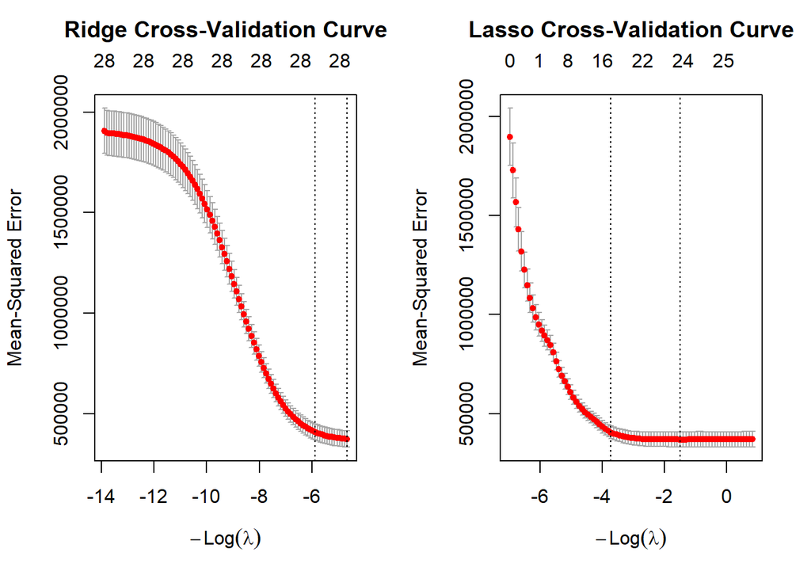

```r
set.seed(123)

# Fit Models with CV
cv_ridge <- cv.glmnet(x, y, alpha = 0)
cv_lasso <- cv.glmnet(x, y, alpha = 1)

# Plot CV Curves for Optimal Lambda
par(mfrow = c(1, 2))
plot(cv_ridge)
title("Ridge Cross-Validation Curve", line = 2.5)
plot(cv_lasso)
title("Lasso Cross-Validation Curve", line = 2.5)
```

```r
par(mfrow = c(1, 1))
```

```r
# Print Optimal Lambdas
cat("\n--- Optimal Lambdas ---\n")
```

```
##
## --- Optimal Lambdas ---
```

```r
cat("Ridge Lambda Min:", cv_ridge$lambda.min, "\n")
```

```
## Ridge Lambda Min: 106.7474
```

```r
cat("Lasso Lambda Min:", cv_lasso$lambda.min, "\n")
```

```
## Lasso Lambda Min: 4.410815
```

```r
# Print Coefficients at Optimal Lambda
cat("\n--- Ridge Coefficients (lambda.min) ---\n")
```

```
##
## --- Ridge Coefficients (lambda.min) ---
```

```r
print(coef(cv_ridge, s = "lambda.min"))
```

```
## 29 x 1 sparse Matrix of class "dgCMatrix"
##               lambda.min
## (Intercept)  1848.174849
## season2       449.364262
## season3       644.788007
## season4       914.526788
## mnth2        -152.599453
## mnth3         -35.700514
## mnth4         333.181327
## mnth5         964.661973
## mnth6         716.347660
## mnth7          92.145774
## mnth8         251.704274
## mnth9         692.875788
## mnth10        631.688155
## mnth11        294.223547
## mnth12        221.934396
## holiday1     -288.578611
## weekday1       -2.885094
## weekday2       37.060192
## weekday3      -12.879793
## weekday4      -14.815880
## weekday5       66.731374
## weekday6      123.430393
## workingday1    76.984185
## weathersit2  -283.797104
## weathersit3 -1494.323026
## temp         1945.951893
## atemp        2050.680152
## hum         -1150.587901
## windspeed   -1881.537309
```

```r
cat("\n--- Lasso Coefficients (lambda.min) ---\n")
```

```
##
## --- Lasso Coefficients (lambda.min) ---
```

```r
print(coef(cv_lasso, s = "lambda.min"))
```

```
## 29 x 1 sparse Matrix of class "dgCMatrix"
##               lambda.min
## (Intercept)  1859.732295
## season2       554.325664
## season3       981.220343
## season4      1268.263717
## mnth2           .
## mnth3          86.854244
## mnth4         455.361541
## mnth5        1140.575681
## mnth6         786.840138
## mnth7           .
## mnth8         136.706946
## mnth9         608.258099
## mnth10        536.468798
## mnth11        163.911624
## mnth12        193.558839
## holiday1     -290.165418
## weekday1        .
## weekday2       32.634705
## weekday3        .
## weekday4       -4.911184
## weekday5       56.611047
## weekday6      118.243892
## workingday1    69.539953
## weathersit2  -291.740314
## weathersit3 -1610.496048
## temp         3545.626122
## atemp          96.436546
## hum         -1242.463299
## windspeed   -1951.135534
```

```r
# Calculate Training RMSE
pred_train_ridge <- predict(cv_ridge, newx = x, s = "lambda.min")
pred_train_lasso <- predict(cv_lasso, newx = x, s = "lambda.min")

cat("\n--- Training Set RMSE ---\n")
```

```
##
## --- Training Set RMSE ---
```

```r
cat("Ridge:", sqrt(mean((y - pred_train_ridge)^2)), "\n")
```

```
## Ridge: 562.7922
```

```r
cat("Lasso:", sqrt(mean((y - pred_train_lasso)^2)), "\n")
```

```
## Lasso: 552.7235
```

## Phase 2 - Part 1b: PCR and PLS

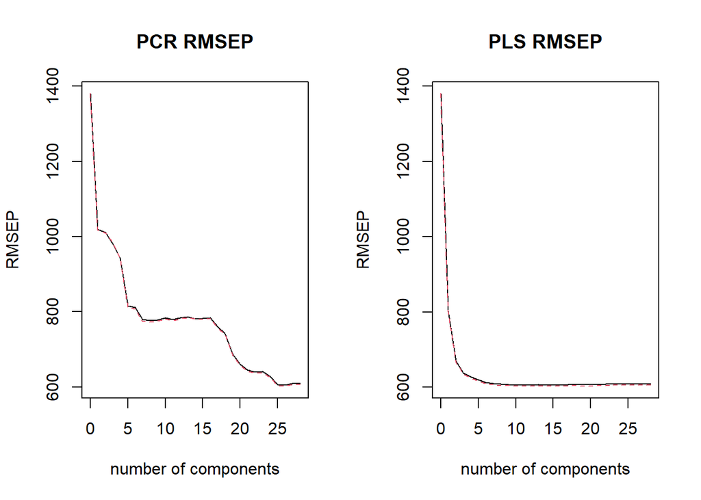

```r
set.seed(123)

# Fit Models
pcr_model <- pcr(cnt ~ ., data = bike_2011_clean, scale = TRUE, validation = "CV")
pls_model <- plsr(cnt ~ ., data = bike_2011_clean, scale = TRUE, validation = "CV")

# Plot RMSEP Curves for Component Selection
par(mfrow = c(1, 2))
plot(RMSEP(pcr_model), main = "PCR RMSEP")
plot(RMSEP(pls_model), main = "PLS RMSEP")
```

```r
par(mfrow = c(1, 1))
```

```r
# Print Summary
cat("\n--- PCR Model Summary ---\n")
```

```
##
## --- PCR Model Summary ---
```

```r
summary(pcr_model)
```

```
## Data:    X dimension: 365 28
##  Y dimension: 365 1
## Fit method: svdpc
## Number of components considered: 28
##
## VALIDATION: RMSEP
## Cross-validated using 10 random segments.
##        (Intercept)  1 comps  2 comps  3 comps  4 comps  5 comps  6 comps
## CV            1381     1020     1011    981.0    944.0    815.9    812.0
## adjCV         1381     1019     1010    984.2    942.1    811.9    807.7
##        7 comps  8 comps  9 comps  10 comps  11 comps  12 comps  13 comps
## CV       780.2    777.0    778.6     783.4     779.9     784.6     787.1
## adjCV    774.5    773.5    775.8     781.7     776.0     781.5     785.2
##        14 comps  15 comps  16 comps  17 comps  18 comps  19 comps  20 comps
## CV        781.3     782.8     784.2     760.1     743.1     686.6     661.1
## adjCV     781.1     780.4     782.0     758.1     741.1     683.6     657.6
##        21 comps  22 comps  23 comps  24 comps  25 comps  26 comps  27 comps
## CV        645.7     640.1     641.7     628.5     606.9     605.1     609.3
## adjCV     643.1     637.3     638.8     626.2     604.0     602.2     606.1
##        28 comps
## CV        610.9
## adjCV     606.5
##
## TRAINING: % variance explained
##      1 comps  2 comps  3 comps  4 comps  5 comps  6 comps  7 comps  8 comps
## X      12.84    21.56    29.00    35.81    41.24    46.38    51.04    55.35
## cnt    46.18    47.50    50.49    54.87    67.28    67.67    70.45    70.61
##      9 comps  10 comps  11 comps  12 comps  13 comps  14 comps  15 comps
## X      59.56     63.76     67.77     71.70     75.62     79.47     83.27
## cnt    70.61     70.73     71.22     71.23     71.26     71.26     71.66
##      16 comps  17 comps  18 comps  19 comps  20 comps  21 comps  22 comps
## X       86.75     89.76     92.55     95.03     96.53     97.87     98.78
## cnt     71.66     72.96     74.65     78.49     80.48     81.45     81.82
##      23 comps  24 comps  25 comps  26 comps  27 comps  28 comps
## X       99.27     99.64     99.94     99.99    100.00     100.0
## cnt     82.11     82.84     83.91     84.05     84.08      84.1
```

```r
cat("\n--- PLS Model Summary ---\n")
```

```
##
## --- PLS Model Summary ---
```

```r
summary(pls_model)
```

[output not shown]

```r
# Optimal Components
pcr_ncomp_opt <- which.min(RMSEP(pcr_model)$val[1,1,]) - 1
pls_ncomp_opt <- which.min(RMSEP(pls_model)$val[1,1,]) - 1

cat("\n--- Optimal Components ---\n")
```

```
##
## --- Optimal Components ---
```

```r
cat("PCR:", pcr_ncomp_opt, "\n")
```

```
## PCR: 26
```

```r
cat("PLS:", pls_ncomp_opt, "\n")
```

```
## PLS: 14
```

```r
# Training RMSE
pred_pcr_train <- predict(pcr_model, bike_2011_clean, ncomp = pcr_ncomp_opt)
pred_pls_train <- predict(pls_model, bike_2011_clean, ncomp = pls_ncomp_opt)

cat("\n--- Training Set RMSE ---\n")
```

```
##
## --- Training Set RMSE ---
```

```r
cat("PCR:", sqrt(mean((bike_2011_clean$cnt - pred_pcr_train)^2)), "\n")
```

```
## PCR: 549.8751
```

```r
cat("PLS:", sqrt(mean((bike_2011_clean$cnt - pred_pls_train)^2)), "\n")
```

```
## PLS: 550.2276
```

## Phase 2 - Part 2: GAM

```r
# Fit GAM with splines for temp, hum, windspeed
gam_model <- gam(
  cnt ~ season + mnth + holiday + weekday + workingday + weathersit +
    s(temp, bs = "cs") +
    s(hum, bs = "cs") +
    s(windspeed, bs = "cs"),
  data = bike_2011
)

# Print Summary
cat("\n--- GAM Model Summary ---\n")
```

```
##
## --- GAM Model Summary ---
```

```r
summary(gam_model)
```

```
##
## Family: gaussian
## Link function: identity
##
## Formula:
## cnt ~ season + mnth + holiday + weekday + workingday + weathersit +
##     s(temp, bs = "cs") + s(hum, bs = "cs") + s(windspeed, bs = "cs")
##
## Parametric coefficients:
##             Estimate Std. Error t value Pr(>|t|)
## (Intercept)  2348.32     160.45  14.636  < 2e-16 ***
## season2       414.20     160.86   2.575  0.01047 *
## season3       875.39     190.70   4.590 6.32e-06 ***
## season4      1188.57     161.54   7.358 1.53e-12 ***
## mnth2         160.50     140.58   1.142  0.25442
## mnth3         262.93     169.64   1.550  0.12214
## mnth4         452.20     246.94   1.831  0.06798 .
## mnth5        1114.56     262.56   4.245 2.85e-05 ***
## mnth6        1033.95     284.26   3.637  0.00032 ***
## mnth7         818.52     315.87   2.591  0.00999 **
## mnth8         431.64     304.07   1.420  0.15670
## mnth9         573.94     274.37   2.092  0.03722 *
## mnth10        381.43     246.97   1.544  0.12345
## mnth11        202.95     243.42   0.834  0.40503
## mnth12        306.82     189.94   1.615  0.10720
## holiday1     -236.77     146.02  -1.621  0.10588
## weekday1     -102.37      64.06  -1.598  0.11099
## weekday2       18.41      69.39   0.265  0.79093
## weekday3      -28.70      70.10  -0.409  0.68253
## weekday4      -33.64      68.72  -0.489  0.62487
## weekday5       22.51      67.79   0.332  0.74012
## weekday6      177.96      94.00   1.893  0.05922 .
## workingday1   112.98      59.89   1.887  0.06010 .
## weathersit2  -232.70      72.59  -3.205  0.00148 **
## weathersit3 -1027.12     200.78  -5.116 5.35e-07 ***
## ---
## Signif. codes:  0 '***' 0.001 '**' 0.01 '*' 0.05 '.' 0.1 ' ' 1
##
## Approximate significance of smooth terms:
##                edf Ref.df      F p-value
## s(temp)      5.312      9 21.342  <2e-16 ***
## s(hum)       6.219      9  7.000  <2e-16 ***
## s(windspeed) 3.278      9  5.391  <2e-16 ***
## ---
## Signif. codes:  0 '***' 0.001 '**' 0.01 '*' 0.05 '.' 0.1 ' ' 1
##
## Rank: 51/52
## R-sq.(adj) =  0.882   Deviance explained = 89.4%
## GCV = 2.5152e+05  Scale est. = 2.2478e+05  n = 365
```

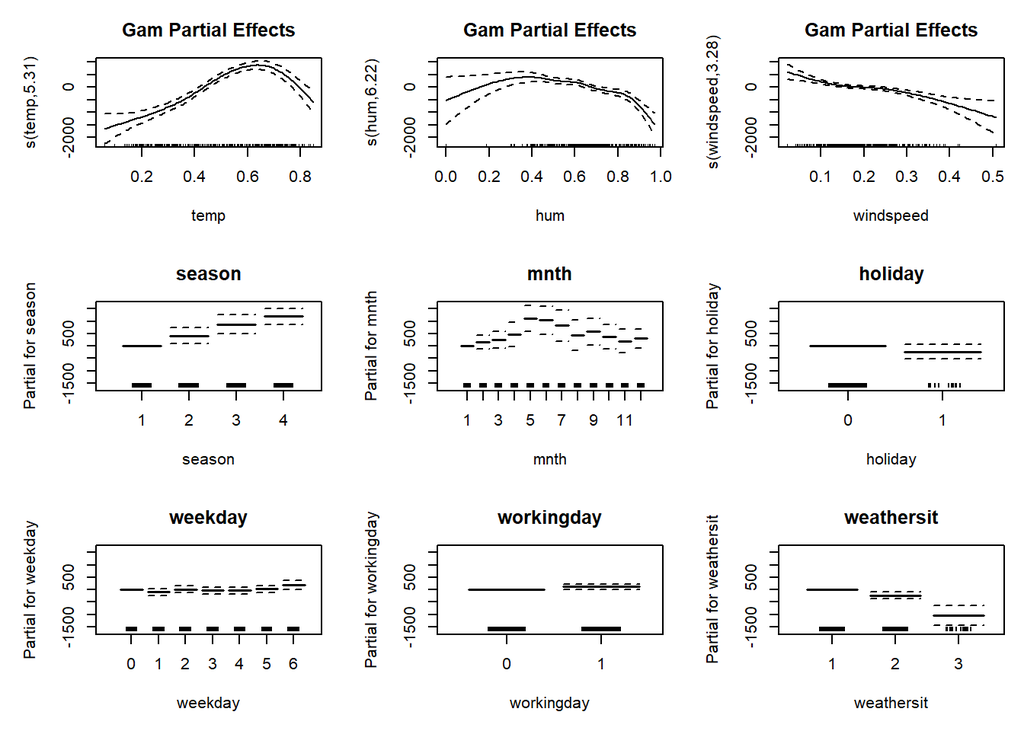

```r
# Plot Partial Effects (all)
plot(gam_model, pages = 1, all.terms = TRUE, main = "Gam Partial Effects")
```

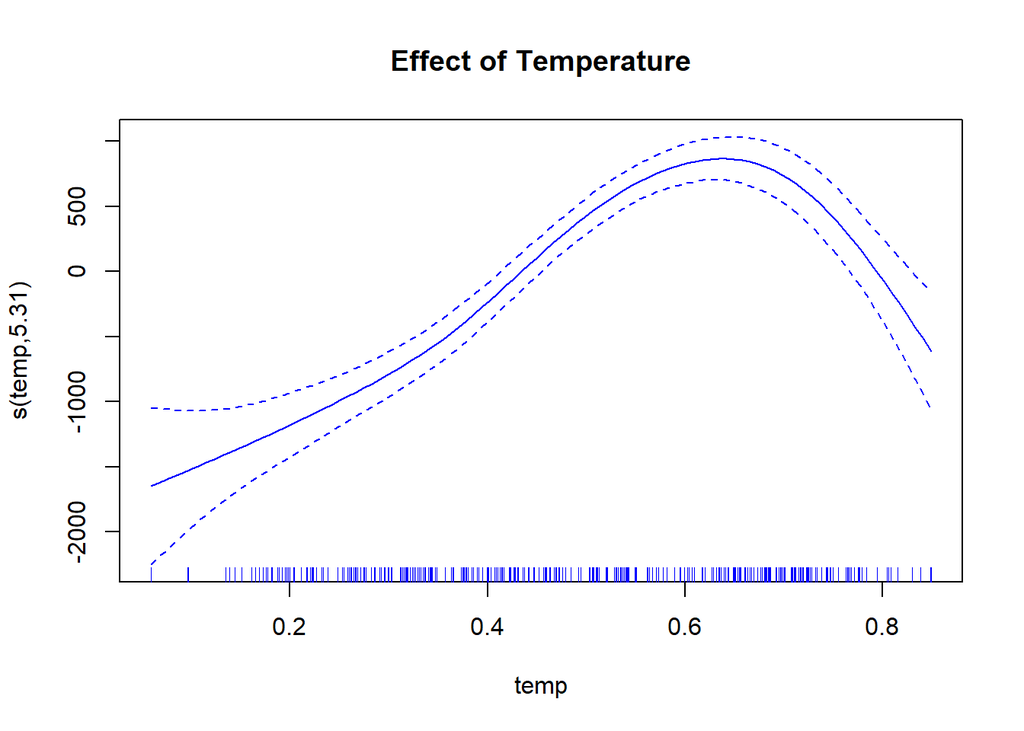

```r
# Plots 3 Spline Terms
plot.gam(gam_model, select = 1, col = "blue", main = "Effect of Temperature")
```

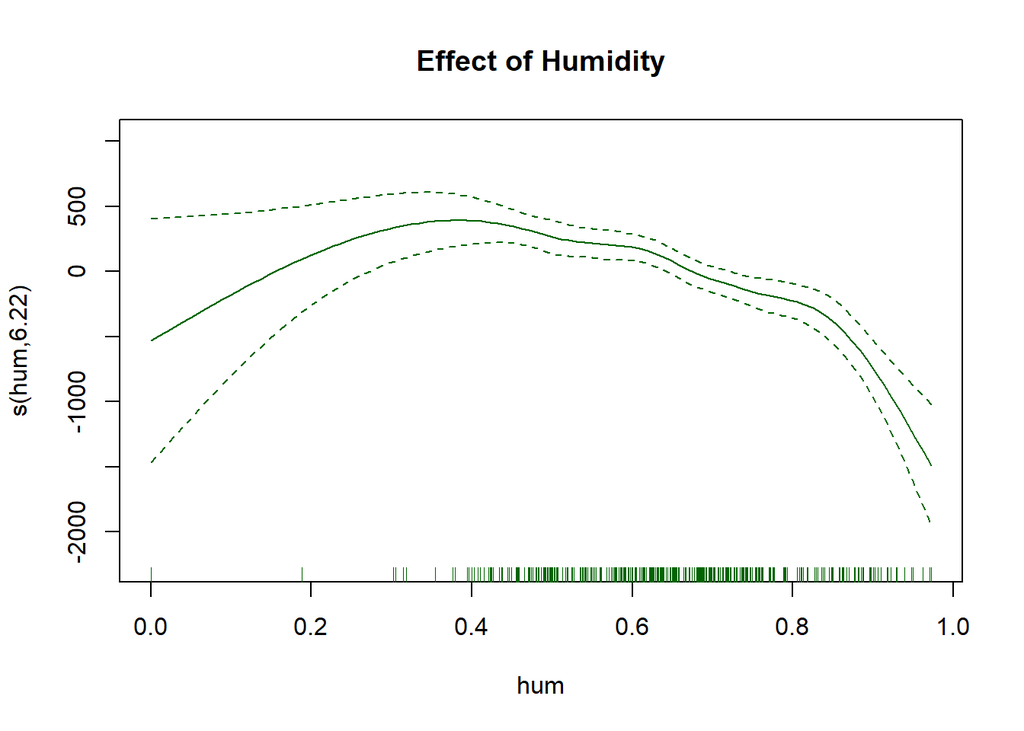

```r
plot.gam(gam_model, select = 2, col = "darkgreen", main = "Effect of Humidity")
```

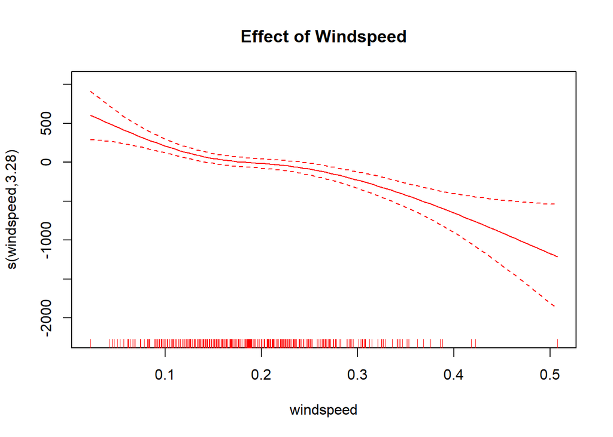

```r
plot.gam(gam_model, select = 3, col = "red", main = "Effect of Windspeed")
```

```r
layout(1)  # reset
```

```r
# Training RMSE
pred_gam_train <- predict(gam_model, newdata = bike_2011)
train_rmse <- sqrt(mean((bike_2011$cnt - pred_gam_train)^2))

cat("\n--- GAM Training Set RMSE ---\n")
```

```
##
## --- GAM Training Set RMSE ---
```

```r
cat("GAM:", train_rmse, "\n")
```

```
## GAM: 448.1978
```

## Phase 2 - Part 3: Test Set Evaluation and Final Model Selection

```r
calc_mae <- function(actual, predicted) { mean(abs(actual - predicted)) }

# Predictions
pred_ridge_test <- predict(cv_ridge, newx = x_test, s = "lambda.min")
pred_lasso_test <- predict(cv_lasso, newx = x_test, s = "lambda.min")
pred_pcr_test <- as.vector(predict(pcr_model, newdata = bike_2012_clean, ncomp = pcr_ncomp_opt))
pred_pls_test <- as.vector(predict(pls_model, newdata = bike_2012_clean, ncomp = pls_ncomp_opt))
pred_gam_test <- predict(gam_model, newdata = bike_2012)

# Compile Results
results <- data.frame(
  Model = c("Ridge", "Lasso", "PCR", "PLS", "GAM"),
  RMSE = c(
    sqrt(mean((y_test - pred_ridge_test)^2)),
    sqrt(mean((y_test - pred_lasso_test)^2)),
    sqrt(mean((bike_2012_clean$cnt - pred_pcr_test)^2)),
    sqrt(mean((bike_2012_clean$cnt - pred_pls_test)^2)),
    sqrt(mean((bike_2012_clean$cnt - pred_gam_test)^2))
  ),
  MAE = c(
    calc_mae(y_test, pred_ridge_test),
    calc_mae(y_test, pred_lasso_test),
    calc_mae(bike_2012_clean$cnt, pred_pcr_test),
    calc_mae(bike_2012_clean$cnt, pred_pls_test),
    calc_mae(bike_2012_clean$cnt, pred_gam_test)
  )
)

cat("\n--- Final Test Set Performance (2012) ---\n")
```

```
##
## --- Final Test Set Performance (2012) ---
```

```r
print(results)
```

```
##   Model     RMSE      MAE
## 1 Ridge 2300.769 2117.747
## 2 Lasso 2290.241 2109.676
## 3   PCR 2299.872 2124.137
## 4   PLS 2295.714 2119.521
## 5   GAM 2210.349 2066.533
```

```r
# Print Best Model
best_model_row <- results[which.min(results$RMSE), ]
cat("\n--- BEST MODEL SELECTED ---\n")
```

```
##
## --- BEST MODEL SELECTED ---
```

```r
print(best_model_row)
```

```
##   Model     RMSE      MAE
## 5   GAM 2210.349 2066.533
```

```r
# --- Training Performance (2011) ---
# Predictions on training data
pred_gam_train <- predict(gam_model, newdata = bike_2011)

# Residuals
resid_train <- bike_2011$cnt - pred_gam_train

# Training metrics
rmse_2011 <- sqrt(mean(resid_train^2))
mae_2011  <- mean(abs(resid_train))

cat("\n--- GAM Training Performance (2011) ---\n")
```

```
##
## --- GAM Training Performance (2011) ---
```

```r
cat("RMSE:", rmse_2011, "\n")
```

```
## RMSE: 448.1978
```

```r
cat("MAE :", mae_2011,  "\n")
```

```
## MAE : 332.1832
```

```r
# --- Test Performance (2012) ---
# Predictions on test data
pred_gam_test <- predict(gam_model, newdata = bike_2012)

# Residuals
resid_test <- bike_2012$cnt - pred_gam_test

# Test metrics
rmse_2012 <- sqrt(mean(resid_test^2))
mae_2012  <- mean(abs(resid_test))

cat("\n--- GAM Test Performance (2012) ---\n")
```

```
##
## --- GAM Test Performance (2012) ---
```

```r
cat("RMSE:", rmse_2012, "\n")
```

```
## RMSE: 2210.349
```

```r
cat("MAE :", mae_2012,  "\n")
```

```
## MAE : 2066.533
```

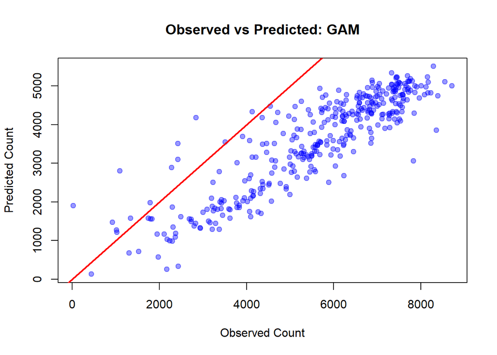

```r
# Observed vs Predicted Plot for GAM
plot(
  bike_2012$cnt, pred_gam_test,
  xlab = "Observed Count",
  ylab = "Predicted Count",
  main = "Observed vs Predicted: GAM",
  pch = 19, col = rgb(0, 0, 1, 0.4)
)
abline(0, 1, col = "red", lwd = 2)
```